# Mutation order probabilities for predicting clonal heterogeneity and treatment response by single-cell analysis

Author: Ken Furudate

2021-02-07

## Contents

1. Setup
2. Data loading
3. Preprocessing
4. Analysis

### 1. Setup

```python
# Import packages
from collections import Counter, defaultdict
from copy import deepcopy
from fractions import Fraction
from IPython.core.display import display, HTML
display(HTML("<style>.container { width:80% !important; }</style>"))
# from IPython.display import display

import numpy as np
from math import sqrt, gamma
import matplotlib
from matplotlib import pyplot as plt
%matplotlib inline
import matplotlib.font_manager
plt.rcParams['font.family'] ='Times New Roman'
plt.rcParams["font.size"] = 16

import pandas as pd
import pymc3 as pm
from scipy.stats import poisson
import seaborn as sns
from sklearn.utils import resample
from statsmodels.stats.weightstats import ttest_ind, ztest
import theano
import theano.tensor as tt
from tqdm import tqdm
import warnings
warnings.simplefilter(action='ignore', category=FutureWarning)
```

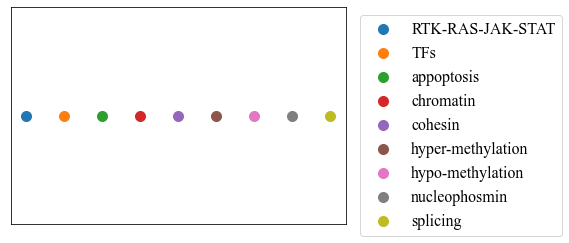

```python
# Assign color for pathway
# https://matplotlib.org/3.1.1/gallery/color/colormap_reference.html

tab10 = list(matplotlib.colors.TABLEAU_COLORS.values())

pathways = [
  'RTK-RAS-JAK-STAT',
  'TFs',
  'appoptosis',
  'chromatin',
  'cohesin',
  'hyper-methylation',
  'hypo-methylation',
  'nucleophosmin',
  'splicing']

pway2color_dic = defaultdict(str)
for i in range(len(pathways)):
  pway2color_dic[pathways[i]] = tab10[i]

f, ax = plt.subplots(1, 1)
for idx, (k, v) in enumerate(pway2color_dic.items()):
    ax.scatter(idx, 1, s=10**2, color=v, label=k)
ax.legend(bbox_to_anchor=(1.02, 1), loc='upper left')
ax.set_xticks([])
ax.set_yticks([])
plt.show()
```

#### Classifying mutated genes by pathways

We classified 31 targeted genes into the pathways in the same functional lineage of the interaction of the multiple genes. NRAS, KRAS, FLT3, PTPN11, KIT, CBL, SETBP1, JAK2, MPL, CSF3R were categorized by Receptor tyrosine kinase (RTK)/Ras GTPase (RAS)/MAP Kinase signaling pathway genes and JAK-STAT pathway genes, refers to as RTK-RAS-JAK-STAT.

Transcription factors pathway genes, refers to as TFs, include RUNX1, WT1, GATA2, PHF6, and ETV6.

Apoptosis genes were TP53, PPM1D, and MYC.

Chromatin genes were ASXL1, BCOR, and EZH2.

We designated IDH1, IDH2, and TET2 hyper-methylation and designated DNMT3A hypo-methylation. This is because that IDH1, IDH2, and TET2, involving in suppression of DNA methylation, and DNMT3A, DNA methyltransferase, are the functional opposite of each other.

Nucleophosmin gene were NPM1.

Splicing genes SRSF2, U2AF1, and SF3B1.

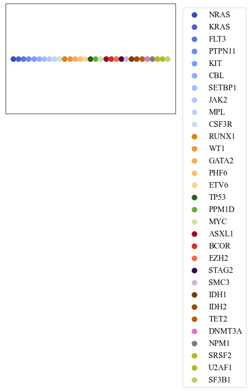

```python
# Classifying mutated genes by pathways
pway2gene_dic = {
    'RTK-RAS-JAK-STAT': ("NRAS", "KRAS", "FLT3", "PTPN11", "KIT", "CBL", "SETBP1", "JAK2", "MPL", "CSF3R"),
    'TFs': ("RUNX1", "WT1", "GATA2", "PHF6", "ETV6"),
    'appoptosis': ("TP53", "PPM1D", "MYC"),
    'chromatin': ("ASXL1", "BCOR", "EZH2"),
    'cohesin': ("STAG2", "SMC3"),
    'hyper-methylation': ("IDH1", "IDH2", "TET2"),
    'hypo-methylation': ("DNMT3A"),
    'methylation': ("IDH1", "IDH2", "TET2", "DNMT3A"),
    'nucleophosmin': ("NPM1"),
    'splicing': ("SRSF2", "U2AF1", "SF3B1")
    }

gene2pway_dic = {
    'ASXL1': 'chromatin',
    'BCOR': 'chromatin',
    'CBL': 'RTK-RAS-JAK-STAT',
    'CSF3R': 'RTK-RAS-JAK-STAT',
    'DNMT3A': 'hypo-methylation',
    'ETV6': 'TFs',
    'EZH2': 'chromatin',
    'FLT3': 'RTK-RAS-JAK-STAT',
    'GATA2': 'TFs',
    'IDH1': 'hyper-methylation',
    'IDH2': 'hyper-methylation',
    'JAK2': 'RTK-RAS-JAK-STAT',
    'KIT': 'RTK-RAS-JAK-STAT',
    'KRAS': 'RTK-RAS-JAK-STAT',
    'MPL': 'RTK-RAS-JAK-STAT',
    'MYC': 'appoptosis',
    'NPM1': 'nucleophosmin',
    'NRAS': 'RTK-RAS-JAK-STAT',
    'PHF6': 'TFs',
    'PPM1D': 'appoptosis',
    'PTPN11': 'RTK-RAS-JAK-STAT',
    'RUNX1': 'TFs',
    'SETBP1': 'RTK-RAS-JAK-STAT',
    'SF3B1': 'splicing',
    'SMC3': 'cohesin',
    'SRSF2': 'splicing',
    'STAG2': 'cohesin',
    'TET2': 'hyper-methylation',
    'TP53': 'appoptosis',
    'U2AF1': 'splicing',
    'WT1': 'TFs'
    }

# Assign colors for gene
gene2color_dic = {
    'ASXL1': '#a50026',
    'BCOR': '#d62f27',
    'CBL': '#8db0fe',
    'CSF3R': '#cfdaea',
    'DNMT3A': '#e377c2',
    'ETV6': '#fed095',
    'EZH2': '#f46d43',
    'FLT3': '#5977e3',
    'GATA2': '#f7ac52',
    'IDH1': '#7f3b08',
    'IDH2': '#9e4c07',
    'JAK2': '#afcafc',
    'KIT': '#7b9ff9',
    'KRAS': '#4961d2',
    'MPL': '#c0d4f5',
    'MYC': '#c7e89f',
    'NPM1': '#7f7f7f',
    'NRAS': '#3b4cc0',
    'PHF6': '#fdbf72',
    'PPM1D': '#6dad36',
    'PTPN11': '#6a8bef',
    'RUNX1': '#e08214',
    'SETBP1': '#9ebeff',
    'SF3B1':  '#bdd16d',
    'SMC3': '#ceb5d7',
    'SRSF2': '#bdb522',
    'STAG2': '#40004b',
    'TET2': '#bb5f08',
    'TP53': '#276419',
    'U2AF1': '#adbd22',
    'WT1': '#eb9733'
    }

f, ax = plt.subplots(1, 1)

idx = 1
for p in pathways:
  gs = pway2gene_dic[p]
  if (gs == "DNMT3A") or (gs == "NPM1") :
    c = gene2color_dic[gs]
    ax.scatter(idx, 1, s=10**2, color=c, label=gs)
    idx += 1
  else:
    for g in gs:
      c = gene2color_dic[g]
      ax.scatter(idx, 1, s=10**2, color=c, label=g)
      idx += 1
ax.legend(bbox_to_anchor=(1.02, 1), loc='upper left')
ax.set_xticks([])
ax.set_yticks([])
plt.show()
```

```python
# Bootstrop Function
# Bishop, CM. Pattern recognition and machine learning. Springer. 23, 656 (2006).
def MkLst(input_df):
  """
  For a given data frame, return gene list that we need for the bootstrap
  """
  gene_lst = []
  for i in range(len(input_df)):
    gene_ = input_df["gene"][i]
    frequency_ = input_df["frequency"][i]

    for _ in range(frequency_):
      gene_lst.append(gene_)

  return gene_lst

def BootStrap(input_df, n_iter=1000):
  """
  This function does bootstrap methods for mutation order probability
  :panam input_df: this is input dataframe
  :param n_iter: number of random sampling with replacement
  """
  input_lst = MkLst(input_df)
  prob_dic = defaultdict(float)
  freaq_dic = defaultdict(float)
  prob_df = pd.DataFrame()
  frequency_lst = []

  for i in tqdm(range(n_iter)):
    resamples =  resample(input_lst, replace=True, n_samples=len(input_lst), random_state=i)
    cnt_resamples = Counter(resamples)

    for k_, v_ in cnt_resamples.items():
      n_samples_ = float(Fraction(v_)/Fraction(len(input_lst)))
      prob_dic[k_] += n_samples_
      freaq_dic[k_] += v_

  for k_ in prob_dic.keys():
    prob_dic[k_] =  float(Fraction(prob_dic[k_])/Fraction(n_iter))
    freaq_dic[k_] = float(Fraction(freaq_dic[k_])/Fraction(n_iter))

  prob_df = pd.DataFrame({"gene":list(prob_dic.keys()), "probability":list(prob_dic.values())})

  prob_df.sort_values(by="probability", ascending=False, inplace=True)
  prob_df.reset_index(drop=True, inplace=True)

  for j in range(len(prob_df)):
    gene_ = prob_df.iloc[:,0][j]
    frequency_lst.append(freaq_dic[gene_])

  prob_df["frequency"] = frequency_lst
  prob_df["frequency"] = prob_df["frequency"].round().astype(int)

  return prob_df

# Function to calculate the 95% confidence interval
# The 95% confidence intervals (CI) was calculated using the Sison and Glaz method in the MultinomCI of R package.
# This is the mathematical details are in Theorem 2.1.(Sison, C.P and Glaz, J., 1995).
# Sison, C.P and Glaz, J. Simultaneous confidence intervals and sample size determination for multinomial proportions. Journal of the American Statistical Association 90, 366-369 (1995).
# http://finzi.psych.upenn.edu/library/DescTools/html/MultinomCI.html
def multinomialCI(x, probs=None, conf=0.95):
  """
  This function is translated to python from R
  https://github.com/cran/MultinomialCI/blob/master/R/sison.R
  """
  x = np.array(x)
  n = sum(x)
  k = len(x)
  c = 0
  pold = 0

  for cc in range(1, n+1):
   poi = _truncpoi(cc, x, n, k)
   if (poi > conf) & (pold < conf):
     c = cc
     break
   pold=poi

  salida = np.zeros((k, 2))
  delta = (conf-pold)/(poi-pold)
  out = np.zeros((k, 5))
  num = np.zeros((k, 1))
  c -= 1
  vol1 = 1
  vol2 = 1

  for i in range(k):
   num[i, 0] = i
   if probs is None:
     obsp = x[i]/n
   else:
     obsp = probs[i]

   out[i, 0] = obsp
   out[i, 1] = obsp-c/n
   out[i, 2] = obsp+c/n+2*delta/n

   if out[i, 1] < 0: out[i, 1] = 0
   if out[i, 2] > 1: out[i, 2] = 1
   out[i, 3] = obsp-c/n-1/n
   out[i, 4] = obsp+c/n+1/n

   if out[i, 1] < 0: out[i, 1] = 0
   if out[i, 2] > 1: out[i, 2] = 1
   vol1 *= (out[i, 2]-out[i, 1])
   vol2 *= (out[i, 4]-out[i, 3])

   salida[i, 0] = out[i, 1]
   salida[i, 1] = out[i, 2]

  cov=100*(conf)
  sg=(x+delta)/n

  return salida

def _moments(c, l):
  """
  This function is translated to python from R
  https://github.com/cran/MultinomialCI/blob/master/R/aux-fn.R
  """
  a = l + c
  b = l - c
  if b<0: b=0
  if b>0: den=poisson.cdf(a, l) - poisson.cdf(b-1, l)
  if b==0: den=poisson.cdf(a, l)

  mu=np.zeros((4, 1))
  mom=np.zeros((5, 1))

  for r in range(1, 5):
    poisA=0
    poisB=0
    if (a-r) >= 0: poisA = poisson.cdf(a, l) - poisson.cdf(a-r, l)
    if (a-r) < 0: poisA = poisson.cdf(a, l)
    if (b-r-1) >=0: poisB = poisson.cdf(b-1, l) - poisson.cdf(b-r-1, l)
    if ((b-r-1) < 0) & ((b-1) >= 0): poisB = poisson.cdf(b-1, l)
    if ((b-r-1) < 0) & ((b-1) < 0): poisB = 0

    mu[r-1, 0] = (l**r)*(1-(poisA-poisB)/den)

  mom[0] = mu[0]
  mom[1] = mu[1]+mu[0]-mu[0]**2
  mom[2] = mu[2]+mu[1]*(3-3*mu[0])+(mu[0]-3*mu[0]**2+2*mu[0]**3)
  mom[3] = mu[3]+mu[2]*(6-4*mu[0])+mu[1]*(7-12*mu[0]+6*mu[0]**2)+mu[0]-4*mu[0]**2+6*mu[0]**3-3*mu[0]**4
  mom[4] = den

  return mom

def _truncpoi(c, x, n, k):
  """
  This function is translated to python from R
  https://github.com/cran/MultinomialCI/blob/master/R/aux-fn.R
  """
  m = np.zeros((k, 5))
  for i in range(k):
    l = x[i]
    mom = _moments(c, l)

    for j in range(5):
      m[i, j] = mom[j]

  for i in range(k):
    m[i, 3] = m[i, 3]-3*m[i, 1]**2

  s=np.sum(m, axis=0)
  s1=s[0]
  s2=s[1]
  s3=s[2]
  s4=s[3]

  probn = 1/(poisson.cdf(n, n)-poisson.cdf(n-1,n))
  z = (n-s1)/sqrt(s2)
  g1 = s3/(s2**(3/2))
  g2 = s4/(s2**2)
  poly = 1+g1*(z**3-3*z)/6+g2*(z**4-6*z**2+3)/24+g1**2*(z**6-15*z**4+45*z**2-15)/72
  f = poly*np.exp(-z**2/2)/(sqrt(2)*gamma(0.5))

  probx=1
  for i in range(k):
    probx = probx*m[i, 4]

  return (probn*probx*f/sqrt(s2))
```

### 2. Data loading

```python
# Set Path
PATH = "/ktlab-project/mutation-order/"
```

```python
INPUT = "AML_muts_order.csv"
```

```python
df = pd.read_csv(PATH + f"input/{INPUT}")
df
```

|  | Sample ID_sub | Gene | Order |
| --- | --- | --- | --- |
| 0 | AML-01-001 | FLT3 | 1 |
| 1 | AML-01-001 | WT1 | 2 |
| 2 | AML-01-001 | NPM1 | 3 |
| 3 | AML-01-001 | WT1 | 4 |
| 4 | AML-02-001 | DNMT3A | 1 |
| ... | ... | ... | ... |
| 525 | AML-122-001 | NPM1 | 2 |
| 526 | AML-123-001 | DNMT3A | 1 |
| 527 | AML-123-001 | TET2 | 2 |
| 528 | AML-123-001 | U2AF1 | 3 |
| 529 | AML-123-001 | RUNX1 | 4 |

530 rows × 3 columns

### 3. Preprocessing

We excluded duplicate mutations of amino acidic change in the same order in the same patients for calculate probabilities.

```python
# Remove duplicate genes in each phylogenic tree.
df = df.drop_duplicates()
df = df.reset_index(drop=True)
df
```

|  | Sample ID_sub | Gene | Order |
| --- | --- | --- | --- |
| 0 | AML-01-001 | FLT3 | 1 |
| 1 | AML-01-001 | WT1 | 2 |
| 2 | AML-01-001 | NPM1 | 3 |
| 3 | AML-01-001 | WT1 | 4 |
| 4 | AML-02-001 | DNMT3A | 1 |
| ... | ... | ... | ... |
| 477 | AML-122-001 | NPM1 | 2 |
| 478 | AML-123-001 | DNMT3A | 1 |
| 479 | AML-123-001 | TET2 | 2 |
| 480 | AML-123-001 | U2AF1 | 3 |
| 481 | AML-123-001 | RUNX1 | 4 |

482 rows × 3 columns

```python
# Extract the branches(mutation order) of all the tree structure

clonotypes = []
clonotype = []
previous_order = 0

for i in range(len(df)):
  if df.iloc[:,2][i] == 1:
    clonotype = []
  elif df.iloc[:,2][i] <= previous_order:
    clonotype = clonotype[:-(previous_order-df.iloc[:,2][i]+1)]
  clonotype.append(df.iloc[:,1][i])
  previous_order = df.iloc[:,2][i]
  clonotype = deepcopy(clonotype)
  clonotypes.append('_'.join(clonotype))

cnt_clonotypes = Counter(clonotypes)
values, counts = zip(*cnt_clonotypes.most_common())
res = pd.DataFrame({"gene":values, "frequency":counts})

orders = []
for i in range(len(res)):
  order_ = len(res.gene[i].split("_"))
  orders.append(order_)

res["order"] = orders
res
```

|  | gene | frequency | order |
| --- | --- | --- | --- |
| 0 | DNMT3A | 21 | 1 |
| 1 | IDH2 | 17 | 1 |
| 2 | TET2 | 15 | 1 |
| 3 | FLT3 | 12 | 1 |
| 4 | NRAS | 11 | 1 |
| ... | ... | ... | ... |
| 300 | DNMT3A_KRAS_NPM1_FLT3 | 1 | 4 |
| 301 | SF3B1_NPM1 | 1 | 2 |
| 302 | DNMT3A_TET2 | 1 | 2 |
| 303 | DNMT3A_TET2_U2AF1 | 1 | 3 |
| 304 | DNMT3A_TET2_U2AF1_RUNX1 | 1 | 4 |

305 rows × 3 columns

### 4. Analysis

|  | gene | probability | frequency | CI_lower | CI_upper | pathway | gene_color | pathway_color |
| --- | --- | --- | --- | --- | --- | --- | --- | --- |
| 0 | DNMT3A | 0.147808 | 21 | 0.08443 | 0.21507 | hypo-methylation | #e377c2 | #e377c2 |
| 1 | IDH2 | 0.119855 | 17 | 0.05647 | 0.18711 | hyper-methylation | #9e4c07 | #8c564b |
| 2 | TET2 | 0.105531 | 15 | 0.04215 | 0.17279 | hyper-methylation | #bb5f08 | #8c564b |
| 3 | FLT3 | 0.084759 | 12 | 0.02138 | 0.15202 | RTK-RAS-JAK-STAT | #5977e3 | #1f77b4 |
| 4 | NRAS | 0.076983 | 11 | 0.01360 | 0.14424 | RTK-RAS-JAK-STAT | #3b4cc0 | #1f77b4 |
| 5 | TP53 | 0.063530 | 9 | 0.00015 | 0.13079 | appoptosis | #276419 | #2ca02c |
| 6 | NPM1 | 0.063406 | 9 | 0.00003 | 0.13066 | nucleophosmin | #7f7f7f | #7f7f7f |
| 7 | SF3B1 | 0.049387 | 7 | 0.00000 | 0.11664 | splicing | #bdd16d | #bcbd22 |
| 8 | WT1 | 0.042061 | 6 | 0.00000 | 0.10932 | TFs | #eb9733 | #ff7f0e |
| 9 | RUNX1 | 0.035477 | 5 | 0.00000 | 0.10273 | TFs | #e08214 | #ff7f0e |
| 10 | IDH1 | 0.035349 | 5 | 0.00000 | 0.10261 | hyper-methylation | #7f3b08 | #8c564b |
| 11 | SRSF2 | 0.028221 | 4 | 0.00000 | 0.09548 | splicing | #bdb522 | #bcbd22 |
| 12 | ASXL1 | 0.028196 | 4 | 0.00000 | 0.09545 | chromatin | #a50026 | #d62728 |
| 13 | KRAS | 0.028183 | 4 | 0.00000 | 0.09544 | RTK-RAS-JAK-STAT | #4961d2 | #1f77b4 |
| 14 | BCOR | 0.014182 | 2 | 0.00000 | 0.08144 | chromatin | #d62f27 | #d62728 |
| 15 | CBL | 0.014144 | 2 | 0.00000 | 0.08140 | RTK-RAS-JAK-STAT | #8db0fe | #1f77b4 |
| 16 | GATA2 | 0.014007 | 2 | 0.00000 | 0.08126 | TFs | #f7ac52 | #ff7f0e |
| 17 | EZH2 | 0.013806 | 2 | 0.00000 | 0.08106 | chromatin | #f46d43 | #d62728 |
| 18 | STAG2 | 0.007224 | 1 | 0.00000 | 0.07448 | cohesin | #40004b | #9467bd |
| 19 | U2AF1 | 0.007089 | 1 | 0.00000 | 0.07435 | splicing | #adbd22 | #bcbd22 |
| 20 | JAK2 | 0.006991 | 1 | 0.00000 | 0.07425 | RTK-RAS-JAK-STAT | #afcafc | #1f77b4 |
| 21 | SETBP1 | 0.006963 | 1 | 0.00000 | 0.07422 | RTK-RAS-JAK-STAT | #9ebeff | #1f77b4 |
| 22 | PTPN11 | 0.006849 | 1 | 0.00000 | 0.07411 | RTK-RAS-JAK-STAT | #6a8bef | #1f77b4 |

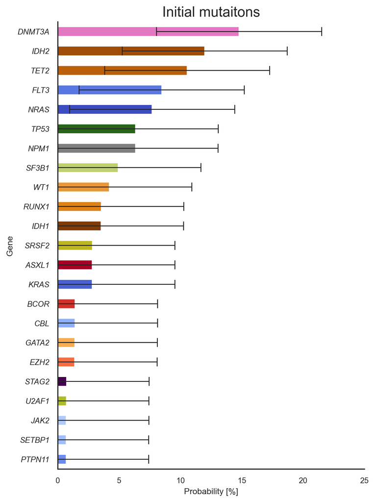

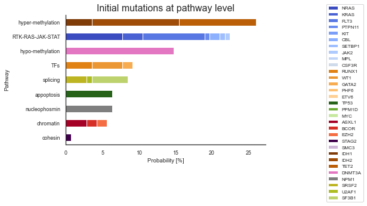

```python
# Calculate initial mutations probabilities
# Applying the bootstrap method (n_iter=10000)

prob_dic = defaultdict(float)
joint_prob_dic = defaultdict(float)
CI_dic = defaultdict(float)

initial_muts = res[res["order"]==1]
initial_muts = initial_muts.reset_index(drop=True)
initial_muts_BS = BootStrap(initial_muts, n_iter=10000)

CI = multinomialCI(list(initial_muts_BS["frequency"]), list(initial_muts_BS["probability"]))
CI[:, 0] = CI[:, 0].round(5)
CI[:, 1] = CI[:, 1].round(5)

CI_lst = []
pway_lst = []
pway_color_lst = []

for i in range(len(initial_muts_BS)):
  prob_ = initial_muts_BS["probability"][i]
  prob_ = round(prob_, 5)
  gene_ = initial_muts_BS["gene"][i]
  prob_dic[gene_] = prob_
  joint_prob_dic[gene_] = prob_
  CI_dic[gene_] = CI[i]
  CI_lst.append(CI[:, 1][i]*100 - prob_*100)
  pway_ = gene2pway_dic[gene_]
  pway_lst.append(pway_)
  pway_color_lst.append(pway2color_dic[pway_])

initial_muts_color = []
for g in initial_muts_BS["gene"]:
  initial_muts_color.append(gene2color_dic[g])

initial_muts_BS["CI_lower"] = CI[:, 0]
initial_muts_BS["CI_upper"] = CI[:, 1]
initial_muts_BS["pathway"] = pway_lst
initial_muts_BS["gene_color"] = initial_muts_color
initial_muts_BS["pathway_color"] = pway_color_lst
display(initial_muts_BS)

# Plot initial mutations
Title = "Initial mutaitons"
sns.set(font_scale=.8, style='white')
plt.figure(figsize=(6, 8), dpi=300)

error_bar_set = dict(lw = 1, capthick = 1, capsize = 5)
plot_df = initial_muts_BS.copy()
plot_df["probability"] = plot_df["probability"]*100
plot_df.sort_values(by="probability", ascending=True, inplace=True)
color_list = plot_df["gene_color"]
plot_df = plot_df.set_index("gene")
plot_df["probability"].plot.barh(color=color_list, xerr=CI_lst, error_kw=error_bar_set)

sns.despine()
plt.title(Title, fontdict={'fontsize':16})
plt.xlabel('Probability [%]')
plt.ylabel('Gene')
plt.xlim([0, 25])
plt.yticks(fontstyle='italic')
plt.tight_layout()

# Plot initial mutations at pathway level
Title = "Initial mutations at pathway level"
sns.set(font_scale=.8, style='white')
plt.figure(figsize=(10, 6), dpi=300)

gene_sequence =[
 "NRAS",
 "KRAS",
 "FLT3",
 "PTPN11",
 "KIT",
 "CBL",
 "SETBP1",
 "JAK2",
 "MPL",
 "CSF3R",
 "RUNX1",
 "WT1",
 "GATA2",
 "PHF6",
 "ETV6",
 "TP53",
 "PPM1D",
 "MYC",
 "ASXL1",
 "BCOR",
 "EZH2",
 "STAG2",
 "SMC3",
 "IDH1",
 "IDH2",
 "TET2",
 "DNMT3A",
 "NPM1",
 "SRSF2",
 "U2AF1",
 "SF3B1",
]

input_df = initial_muts_BS.groupby(by=["gene", "pathway"], as_index=False).count().iloc[:,0:3]
g_lst = list(input_df["gene"])
p_lst = list(set(input_df["pathway"]))
input_df = input_df.set_index("gene")
plot_df2 = np.zeros((len(p_lst), len(g_lst)))
plot_df2 = pd.DataFrame(plot_df2, index=p_lst, columns=g_lst)

for p_ in p_lst:
  gene_ = input_df[input_df["pathway"]==p_].index.values
  for g_ in gene_:
    plot_df2.at[p_, g_] = plot_df.at[g_, "probability"]

re_index = list(plot_df2.sum(axis=1).sort_values().index)
plot_df2 = plot_df2.reindex(index=re_index)
plot_df2 = plot_df2.reindex(columns=gene_sequence)
plot_df2 = plot_df2.fillna(0.0)
plot_df2.plot.barh(stacked=True, color=gene2color_dic)

plt.legend(fontsize=8,loc='upper right', bbox_to_anchor=(1.5, 1.1))
plt.title(Title, fontdict={'fontsize':16})
plt.xlabel('Probability [%]')
plt.ylabel('Pathway')
sns.despine()
plt.show()
```

```python
# Obtain the probability of mutation order
# Applying the bootstrap method (n_iter=10000)

initial_muts = []
initial_muts_prob = []
for g in res["gene"]:
  g_ = g.split("_")[0]
  initial_muts.append(g_)
  initial_muts_prob.append(prob_dic[g_])

res["initial_mutations"] = initial_muts
res["initial_mutations_prob"] = initial_muts_prob

# previous_order_gene
previous_order = []
for genes_ in res["gene"]:
  gene_lst = genes_.split("_")
  if len(gene_lst) == 1:
    previous_order.append("root")

  elif len(gene_lst) > 1:
    gene_lst = gene_lst[:len(gene_lst)-1]
    gene_lst = deepcopy(gene_lst)
    previous_order.append('_'.join(gene_lst))

res["previous_order"] = previous_order

for previous_order_ in res["previous_order"].unique():
  if previous_order_ == "root": continue
  print(f"################ {previous_order_} processing ################")

  child_df = res[res["previous_order"]==previous_order_]
  child_df = child_df.reset_index(drop=True)
  child_df_BS = BootStrap(child_df, n_iter=10000)

  CI = multinomialCI(list(child_df_BS["frequency"]), list(child_df_BS["probability"]))
  CI[:, 0] = CI[:, 0].round(5)
  CI[:, 1] = CI[:, 1].round(5)

  for i in range(len(child_df_BS)):
    gene_ = child_df_BS["gene"][i]
    prob_ = child_df_BS["probability"][i]
    prob_ = round(prob_, 5)
    prob_dic[gene_] = prob_

    previous_prob = joint_prob_dic[previous_order_]
    joint_prob = previous_prob * prob_
    joint_prob = round(joint_prob, 5)
    joint_prob_dic[gene_] = joint_prob
    CI_dic[gene_] = CI[i]

cond_prob = []
joint_prob = []
CI = []
for gene_ in res["gene"]:
  cond_prob.append(prob_dic[gene_])
  joint_prob.append(joint_prob_dic[gene_])
  CI.append(CI_dic[gene_])

res["cond_prob"] = cond_prob
res["CI_cond_prob"] = CI
res["joint_prob"] = joint_prob

for i in range(len(res)):
  if res["frequency"][i]==1:
    res["CI_cond_prob"][i][0]=0.0

# Calculate the unobserved patterns
uni_orders = sorted(res["order"].unique())
max_order = max(res["order"])
Gene = []
Frequency = []
Order = []
initial_muts	= []
initial_muts_prob = []
Previous_order = []
Cond_prob	= []
CI_cond_prob = []
Joint_prob = []

for order_ in uni_orders[1:]:
  current_df = res[res["order"] == order_]
  previous_df = res[res["order"] == (order_ - 1)]
  previous_genes = list(previous_df["gene"])
  current_genes = list(current_df["previous_order"])

  for previous_gene in previous_genes:
    if previous_gene in current_genes: continue
    Gene.append(f"{previous_gene}_nan")
    Frequency.append(1)
    Order.append(order_)
    g_ = previous_gene.split("_")[0]
    initial_muts.append(g_)
    initial_muts_prob.append(prob_dic[g_])
    Previous_order.append(previous_gene)
    Cond_prob.append(1.0000)
    CI_cond_prob.append([1.0, 1.0])
    Joint_prob.append(joint_prob_dic[previous_gene])
    joint_prob_dic[f"{previous_gene}_nan"] = joint_prob_dic[previous_gene]

  for i in range(len(Gene)):
    if Order[i] == max_order: break
    if f"{Gene[i]}_nan" in Gene: continue
    Gene.append(f"{Gene[i]}_nan")
    Frequency.append(1)
    Order.append(Order[i]+1)
    g_ = Gene[i].split("_")[0]
    initial_muts.append(g_)
    initial_muts_prob.append(prob_dic[g_])
    Previous_order.append(Gene[i])
    Cond_prob.append(1.0000)
    CI_cond_prob.append([1.0, 1.0])
    Joint_prob.append(joint_prob_dic[Gene[i]])
    joint_prob_dic[f"{Gene[i]}_nan"] = joint_prob_dic[Gene[i]]

na_res = pd.DataFrame({
    "gene": Gene,
    "frequency": Frequency,
    "order": Order,
    "initial_mutations": initial_muts,
    "initial_mutations_prob": initial_muts_prob,
    "previous_order": Previous_order,
    "cond_prob": Cond_prob,
    "CI_cond_prob": CI_cond_prob,
    "joint_prob": Joint_prob
    })

res2 = pd.concat([res, na_res], axis=0, ignore_index=True)

CI_joint_dic = {}
for order_ in res2["order"].unique():
  order_df = res2[res2["order"] == order_]
  order_df = order_df.reset_index(drop=True)
  frequency_ = list(order_df["frequency"])
  joint_prob_ = list(order_df["joint_prob"])
  CI_joint_ = multinomialCI(frequency_, joint_prob_)
  CI_joint_[:, 0] = CI_joint_[:, 0].round(5)
  CI_joint_[:, 1] = CI_joint_[:, 1].round(5)

  for i in range(len(order_df)):
    gene_ = order_df["gene"][i]
    CI_joint_dic[gene_] = CI_joint_[i]

CI_joint = []
for g_ in res2["gene"]:
  CI_joint.append(CI_joint_dic[g_])
res2["CI_joint_prob"] = CI_joint

None_genes = []
for gene in res2["gene"]:
  g_ = gene.split("_")[-1]
  if g_ == "nan":
    None_genes.append(1)
  else:
    None_genes.append(0)
res2["None_genes"] = None_genes
display(res2)

print("done!")
```

```
################ DNMT3A processing ################
```

```
################ NPM1 processing ################
```

```
################ IDH2 processing ################
```

```
################ DNMT3A_NPM1 processing ################
```

```
################ TET2 processing ################
```

```
################ IDH2_DNMT3A processing ################
```

```
################ IDH2_NPM1 processing ################
```

```
################ FLT3 processing ################
```

```
################ IDH1 processing ################
```

```
################ ASXL1 processing ################
```

```
################ NRAS processing ################
```

```
################ DNMT3A_NRAS processing ################
```

```
################ WT1 processing ################
```

```
################ BCOR processing ################
```

```
################ RUNX1 processing ################
```

```
################ SF3B1 processing ################
```

```
################ TP53 processing ################
```

```
################ FLT3_WT1 processing ################
```

```
################ FLT3_WT1_NPM1 processing ################
```

```
################ DNMT3A_SF3B1 processing ################
```

```
################ DNMT3A_SF3B1_FLT3 processing ################
```

```
################ DNMT3A_SF3B1_FLT3_RUNX1 processing ################
```

```
################ SF3B1_SRSF2 processing ################
```

```
################ SF3B1_SRSF2_FLT3 processing ################
```

```
################ SF3B1_SRSF2_FLT3_WT1 processing ################
```

```
################ SF3B1_SRSF2_NRAS processing ################
```

```
################ IDH2_SRSF2 processing ################
```

```
################ WT1_GATA2 processing ################
```

```
################ WT1_GATA2_MPL processing ################
```

```
################ WT1_GATA2_MPL_SRSF2 processing ################
```

```
################ CBL processing ################
```

```
################ CBL_TET2 processing ################
```

```
################ CBL_TET2_ASXL1 processing ################
```

```
################ IDH2_WT1 processing ################
```

```
################ NRAS_DNMT3A processing ################
```

```
################ IDH2_RUNX1 processing ################
```

```
################ FLT3_RUNX1 processing ################
```

```
################ WT1_NPM1 processing ################
```

```
################ KRAS processing ################
```

```
################ TET2_DNMT3A processing ################
```

```
################ TET2_DNMT3A_U2AF1 processing ################
```

```
################ TET2_DNMT3A_U2AF1_FLT3 processing ################
```

```
################ EZH2 processing ################
```

```
################ EZH2_ASXL1 processing ################
```

```
################ EZH2_ASXL1_RUNX1 processing ################
```

```
################ DNMT3A_FLT3 processing ################
```

```
################ DNMT3A_FLT3_TP53 processing ################
```

```
################ DNMT3A_IDH1 processing ################
```

```
################ DNMT3A_IDH1_NPM1 processing ################
```

```
################ ASXL1_SRSF2 processing ################
```

```
################ ASXL1_SRSF2_RUNX1 processing ################
```

```
################ DNMT3A_NPM1_NRAS processing ################
```

```
################ DNMT3A_SF3B1_RUNX1 processing ################
```

```
################ SRSF2 processing ################
```

```
################ SRSF2_IDH2 processing ################
```

```
################ NPM1_IDH2 processing ################
```

```
################ NPM1_IDH1 processing ################
```

```
################ SF3B1_GATA2 processing ################
```

```
################ TP53_WT1 processing ################
```

```
################ TP53_WT1_IDH2 processing ################
```

```
################ TP53_WT1_IDH2_SRSF2 processing ################
```

```
################ EZH2_NRAS processing ################
```

```
################ EZH2_NRAS_ASXL1 processing ################
```

```
################ EZH2_NRAS_ASXL1_STAG2 processing ################
```

```
################ EZH2_NRAS_ASXL1_STAG2_RUNX1 processing ################
```

```
################ EZH2_NRAS_ASXL1_RUNX1 processing ################
```

```
################ WT1_FLT3 processing ################
```

```
################ RUNX1_WT1 processing ################
```

```
################ ASXL1_KRAS processing ################
```

```
################ BCOR_PTPN11 processing ################
```

```
################ BCOR_PTPN11_DNMT3A processing ################
```

```
################ NRAS_FLT3 processing ################
```

```
################ FLT3_ASXL1 processing ################
```

```
################ SRSF2_RUNX1 processing ################
```

```
################ SRSF2_RUNX1_IDH1 processing ################
```

```
################ SRSF2_RUNX1_IDH1_ASXL1 processing ################
```

```
################ DNMT3A_IDH2 processing ################
```

```
################ IDH1_RUNX1 processing ################
```

```
################ IDH1_RUNX1_DNMT3A processing ################
```

```
################ IDH2_ASXL1 processing ################
```

```
################ IDH2_ASXL1_SRSF2 processing ################
```

```
################ NPM1_PTPN11 processing ################
```

```
################ IDH1_NPM1 processing ################
```

```
################ IDH2_DNMT3A_SRSF2 processing ################
```

```
################ ASXL1_SRSF2_PTPN11 processing ################
```

```
################ DNMT3A_ASXL1 processing ################
```

```
################ DNMT3A_ASXL1_BCOR processing ################
```

```
################ DNMT3A_ASXL1_BCOR_DNMT3A processing ################
```

```
################ DNMT3A_ASXL1_STAG2 processing ################
```

```
################ DNMT3A_ASXL1_STAG2_BCOR processing ################
```

```
################ DNMT3A_ASXL1_STAG2_BCOR_U2AF1 processing ################
```

```
################ DNMT3A_ASXL1_STAG2_BCOR_U2AF1_U2AF1 processing ################
```

```
################ DNMT3A_ASXL1_STAG2_BCOR_U2AF1_U2AF1_NRAS processing ################
```

```
################ DNMT3A_FLT3_NPM1 processing ################
```

```
################ IDH2_KRAS processing ################
```

```
################ IDH2_KRAS_SRSF2 processing ################
```

```
################ TET2_DNMT3A_ASXL1 processing ################
```

```
################ TET2_DNMT3A_ASXL1_NRAS processing ################
```

```
################ TET2_DNMT3A_ASXL1_NRAS_TET2 processing ################
```

```
################ TET2_DNMT3A_ASXL1_NRAS_TET2_DNMT3A processing ################
```

```
################ TET2_PTPN11 processing ################
```

```
################ TET2_PTPN11_DNMT3A processing ################
```

```
################ U2AF1 processing ################
```

```
################ U2AF1_DNMT3A processing ################
```

```
################ U2AF1_DNMT3A_NRAS processing ################
```

```
################ CBL_SETBP1 processing ################
```

```
################ CBL_SETBP1_U2AF1 processing ################
```

```
################ CBL_SETBP1_U2AF1_IDH2 processing ################
```

```
################ CBL_SETBP1_U2AF1_IDH2_RUNX1 processing ################
```

```
################ CBL_SETBP1_U2AF1_IDH2_RUNX1_ASXL1 processing ################
```

```
################ CBL_SETBP1_U2AF1_IDH2_RUNX1_ASXL1_DNMT3A processing ################
```

```
################ TET2_TP53 processing ################
```

```
################ IDH1_DNMT3A processing ################
```

```
################ IDH1_DNMT3A_PTPN11 processing ################
```

```
################ IDH1_DNMT3A_PTPN11_NPM1 processing ################
```

```
################ ASXL1_PHF6 processing ################
```

```
################ ASXL1_PHF6_FLT3 processing ################
```

```
################ ASXL1_PHF6_FLT3_RUNX1 processing ################
```

```
################ GATA2 processing ################
```

```
################ FLT3_MYC processing ################
```

```
################ SF3B1_FLT3 processing ################
```

```
################ SF3B1_FLT3_TET2 processing ################
```

```
################ SF3B1_FLT3_TET2_DNMT3A processing ################
```

```
################ SF3B1_FLT3_TET2_DNMT3A_NPM1 processing ################
```

```
################ TET2_SF3B1 processing ################
```

```
################ TET2_SF3B1_NRAS processing ################
```

```
################ TET2_SF3B1_NRAS_NPM1 processing ################
```

```
################ TET2_SF3B1_NRAS_NPM1_TP53 processing ################
```

```
################ TET2_ASXL1 processing ################
```

```
################ TET2_ASXL1_RUNX1 processing ################
```

```
################ TET2_ASXL1_RUNX1_KIT processing ################
```

```
################ RUNX1_JAK2 processing ################
```

```
################ TET2_IDH2 processing ################
```

```
################ TET2_IDH2_ASXL1 processing ################
```

```
################ TET2_IDH1 processing ################
```

```
################ TET2_IDH1_STAG2 processing ################
```

```
################ TET2_FLT3 processing ################
```

```
################ BCOR_PTPN11_KIT processing ################
```

```
################ DNMT3A_IDH2_RUNX1 processing ################
```

```
################ DNMT3A_IDH2_RUNX1_SRSF2 processing ################
```

```
################ TET2_DNMT3A_PTPN11 processing ################
```

```
################ TET2_DNMT3A_PTPN11_IDH2 processing ################
```

```
################ TET2_DNMT3A_PTPN11_IDH2_NPM1 processing ################
```

```
################ TET2_DNMT3A_SMC3 processing ################
```

```
################ TP53_TP53 processing ################
```

```
################ FLT3_WT1_DNMT3A processing ################
```

```
################ FLT3_WT1_DNMT3A_NPM1 processing ################
```

```
################ TET2_U2AF1 processing ################
```

```
################ TET2_U2AF1_DNMT3A processing ################
```

```
################ RUNX1_DNMT3A processing ################
```

```
################ RUNX1_DNMT3A_U2AF1 processing ################
```

```
################ SETBP1 processing ################
```

```
################ SETBP1_RUNX1 processing ################
```

```
################ SETBP1_RUNX1_ASXL1 processing ################
```

```
################ TET2_DNMT3A_KIT processing ################
```

```
################ TET2_DNMT3A_KIT_TET2 processing ################
```

```
################ STAG2 processing ################
```

```
################ STAG2_DNMT3A processing ################
```

```
################ DNMT3A_ETV6 processing ################
```

```
################ DNMT3A_ETV6_SETBP1 processing ################
```

```
################ DNMT3A_ETV6_SETBP1_EZH2 processing ################
```

```
################ TET2_TET2 processing ################
```

```
################ TP53_DNMT3A processing ################
```

```
################ TET2_TET2_SRSF2 processing ################
```

```
################ SF3B1_IDH1 processing ################
```

```
################ SF3B1_DNMT3A processing ################
```

```
################ DNMT3A_KRAS processing ################
```

```
################ DNMT3A_KRAS_NPM1 processing ################
```

```
################ DNMT3A_TET2 processing ################
```

```
################ DNMT3A_TET2_U2AF1 processing ################
```

|  | gene | frequency | order | initial_mutations | initial_mutations_prob | previous_order | cond_prob | CI_cond_prob | joint_prob | CI_joint_prob | None_genes |
| --- | --- | --- | --- | --- | --- | --- | --- | --- | --- | --- | --- |
| 0 | DNMT3A | 21 | 1 | DNMT3A | 0.14781 | root | 0.14781 | [0.08443, 0.21507] | 0.14781 | [0.08443, 0.21507] | 0 |
| 1 | IDH2 | 17 | 1 | IDH2 | 0.11985 | root | 0.11985 | [0.05647, 0.18711] | 0.11985 | [0.05647, 0.18711] | 0 |
| 2 | TET2 | 15 | 1 | TET2 | 0.10553 | root | 0.10553 | [0.04215, 0.17279] | 0.10553 | [0.04215, 0.17279] | 0 |
| 3 | FLT3 | 12 | 1 | FLT3 | 0.08476 | root | 0.08476 | [0.02138, 0.15202] | 0.08476 | [0.02138, 0.15202] | 0 |
| 4 | NRAS | 11 | 1 | NRAS | 0.07698 | root | 0.07698 | [0.0136, 0.14424] | 0.07698 | [0.0136, 0.14424] | 0 |
| ... | ... | ... | ... | ... | ... | ... | ... | ... | ... | ... | ... |
| 897 | SF3B1_FLT3_TET2_DNMT3A_NPM1_FLT3_nan_nan | 1 | 8 | SF3B1 | 0.04939 | SF3B1_FLT3_TET2_DNMT3A_NPM1_FLT3_nan | 1.00000 | [1.0, 1.0] | 0.01428 | [0.0, 0.04917] | 1 |
| 898 | TET2_SF3B1_NRAS_NPM1_TP53_CBL_nan_nan | 1 | 8 | TET2 | 0.10553 | TET2_SF3B1_NRAS_NPM1_TP53_CBL_nan | 1.00000 | [1.0, 1.0] | 0.00309 | [0.0, 0.03798] | 1 |
| 899 | TET2_DNMT3A_PTPN11_IDH2_NPM1_FLT3_nan_nan | 1 | 8 | TET2 | 0.10553 | TET2_DNMT3A_PTPN11_IDH2_NPM1_FLT3_nan | 1.00000 | [1.0, 1.0] | 0.00495 | [0.0, 0.03984] | 1 |
| 900 | DNMT3A_ASXL1_STAG2_BCOR_U2AF1_U2AF1_KRAS_nan | 1 | 8 | DNMT3A | 0.14781 | DNMT3A_ASXL1_STAG2_BCOR_U2AF1_U2AF1_KRAS | 1.00000 | [1.0, 1.0] | 0.00155 | [0.0, 0.03644] | 1 |
| 901 | TET2_DNMT3A_ASXL1_NRAS_TET2_DNMT3A_RUNX1_nan | 1 | 8 | TET2 | 0.10553 | TET2_DNMT3A_ASXL1_NRAS_TET2_DNMT3A_RUNX1 | 1.00000 | [1.0, 1.0] | 0.00499 | [0.0, 0.03988] | 1 |

902 rows × 11 columns

```
done!
```